# Statistical Methods for Discrete Response, Time Series, and Panel Data (W271): Group Lab 3

# U.S. traffic fatalities: 1980-2004

In this lab, you are asked to answer the question **“Do changes in traffic laws affect traffic fatalities?”** To do so, you will conduct the tasks specified below using the data set *driving.Rdata*, which includes 25 years of data that cover changes in various state drunk driving, seat belt, and speed limit laws.

Specifically, this data set contains data for the 48 continental U.S. states from 1980 through 2004. Various driving laws are indicated in the data set, such as the alcohol level at which drivers are considered legally intoxicated. There are also indicators for “per se” laws—where licenses can be revoked without a trial—and seat belt laws. A few economics and demographic variables are also included. The description of the each of the variables in the dataset is come with the dataste.

**Exercises:**

1. (30%) Load the data. Provide a description of the basic structure of the dataset, as we have done throughout the semester. Conduct a very thorough EDA, which should include both graphical and tabular techniques, on the dataset, including both the dependent variable *totfatrte* and the potential explanatory variables. You need to write a detailed narrative of your observations of your EDA. *Reminder: giving an “output dump” (i.e. providing a bunch of graphs and tables without description and hoping your audience will interpret them) will receive a zero in this exercise.*

Figure displays the total fatality rate over time for each of the 48 states. Most of the states have declining or steady fatality rate, with New Mexico, Nevada and Montana having the largest declines. Exceptions to this pattern were Wyoming, which shows a u-shaped pattern for fatality rate, and Missipissipi, which has a slight increasing trend. Both of these states are among the states with highest average fatality rate.

```r
load("driving.RData")

paste(length(unique(data$year)), min(data$year), max(data$year), unique(table(data$year)))
```

```
## [1] "25 1980 2004 48"
```

```r
paste(length(unique(data$state)), unique(table(data$state)))
```

```
## [1] "48 25"
```

```r
unique(table(data$year, data$state))
```

```
## [1] 1
```

```r
summary(data$totfatrte)
```

```
##    Min. 1st Qu.  Median    Mean 3rd Qu.    Max.
##    6.20   14.38   18.43   18.92   22.77   53.32
```

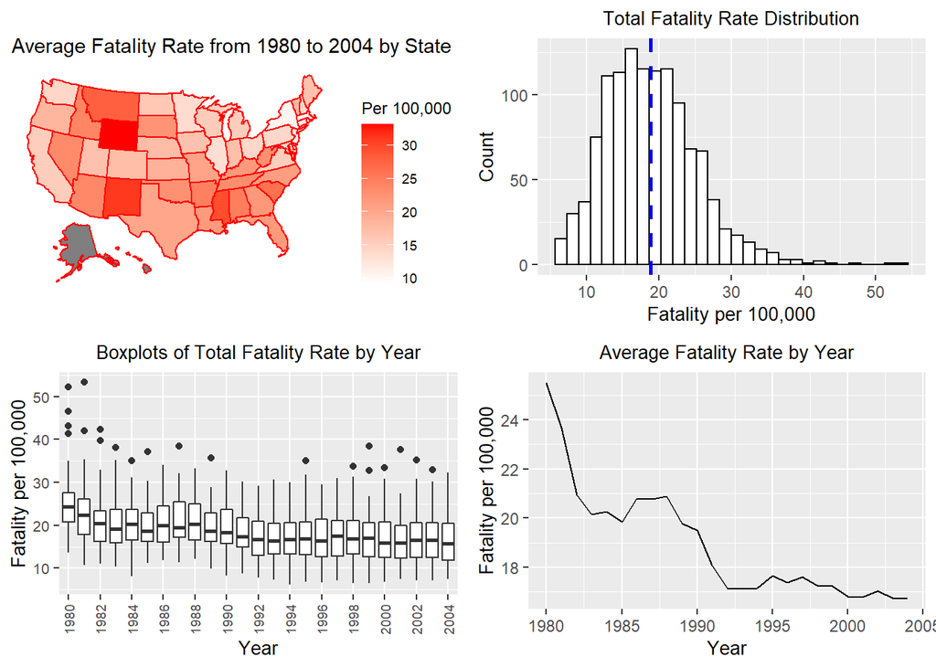

Univariate Analysis of Total Fatality Rate

```r
# merge with state codes
fips_map <-read.csv("statecodes.csv")
data <- merge(x=data, y=fips_map, by="state",all.x = TRUE) %>% dplyr::select(-state)
data <- dplyr::rename(data, c("state"="code"))

state_avg <- data %>% group_by(state) %>% summarise(avg_totfatrte=mean(totfatrte), .groups = 'drop')

# format options for combined plots
formatting <- theme(plot.title = element_text(hjust = 0.5, size=10),
               axis.title.x = element_text(size = 10),
               axis.title.y = element_text(size = 10),
               legend.title = element_text(size = 10))

tickformat <- theme(legend.position = "bottom", axis.text.y = element_text(size = 8),
                    axis.text.x = element_text(angle=90, vjust = 0.5, hjust=1, size = 7))

# functions for making histograms, boxplots and scatterplots
plotbox <- function (df, ycol, ylab){
          ggplot(data, aes(factor(year), get(ycol))) +
                          geom_boxplot() +
                          labs(y=ylab, x = "Year") +
                          formatting + tickformat +
                          scale_x_discrete(breaks=seq(1980, 2004, 2))}

plothist <- function(df, xcol, xlab){
  ggplot(df, aes(x=get(xcol)))+
      geom_histogram(color="black", fill = "white")+
      labs(y='Count', x =xlab)+
      formatting +
      geom_vline(aes(xintercept=mean(get(xcol))),
            color="blue", linetype="dashed", size=1)
}

plotscatter <- function(df, xcol, xlab){
  ggplot(df, aes(x=get(xcol), y=totfatrte)) + geom_point()+
  geom_smooth(method=lm, se=FALSE) + ggtitle(paste(xcol,' vs tolfatrte'))+
  xlab(xlab) + ylab('Fatality Per 100,000') + formatting
}

p1 <- plot_usmap(data = state_avg,  values="avg_totfatrte", color = "red") +
  scale_fill_continuous(name="Per 100,000", low="white", high="red") +
  theme(legend.position = "right") +ggtitle("Average Fatality Rate from 1980 to 2004 by State")

p2 <- plothist(data, "totfatrte", "Fatality per 100,000") +  ggtitle("Total Fatality Rate Distribution")
p3 <- plotbox(data, "totfatrte", "Fatality per 100,000") +  ggtitle("Boxplots of Total Fatality Rate by Year")

year_avg <- data %>% group_by(year) %>% summarise(avg_totfatrte=mean(totfatrte))
p4 <- ggplot(data=year_avg, aes(x=year, y=avg_totfatrte)) +
  geom_line()+ ggtitle("Average Fatality Rate by Year") +
  xlab('Year') + ylab('Fatality per 100,000')+ formatting


grid.arrange(p1,p2,p3,p4, nrow = 2)
```

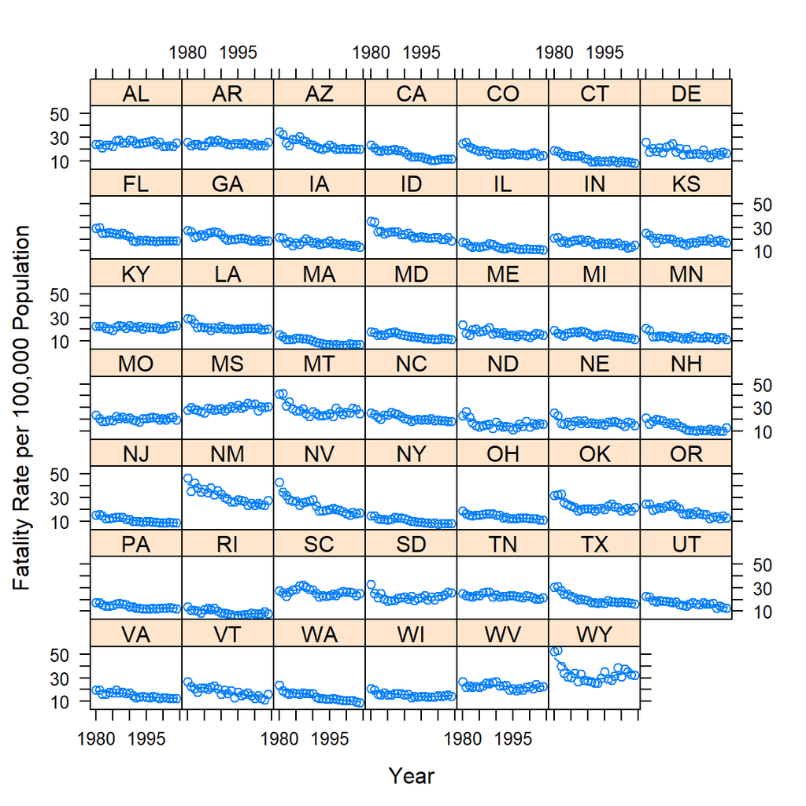

Total Fatality Rate by State

```r
xyplot(totfatrte~year | state, data=data,
       prepanel = function(x, y) prepanel.loess(x, y, family="gaussian"),
       xlab = "Year", ylab = "Fatality Rate per 100,000 Population",
       panel = function(x, y) {
          panel.xyplot(x, y)
          panel.loess(x,y, family="gaussian") },
       as.table=T)
```

In addition to the indicies and fatality measures, the panel data set contains 25 dummies variables representing each year in the dataset. The remaining columns are potential explanatory variables. State population size `statepop` is not pertinent to this study since fatality rate is per 100,000 people. There are four variables not directly related to traffic laws. Minimum drinking age (`minage`) ranges from 18 to 21 in the panel dataset. Starting in 1989, all states require minimal age of 21 to drink, so for most of the data set, `minage` is time invariant, and it is not included in the regression.

Figure shows the univariate and bivariate EDA of the other three variables, `perc14_24`, `unem` and `vehicmilespc`.Percent population aged 14 through 24 (`perc14_24`) ranges from 11.7 to 20.30 with median of 14.9. It is steadily decreasing until 1990, at which point it remains steady. Its variance is higher in the 90s, and every years since 1990 has at least one high outlier. Unemployment Rate Percentage (`unem`) ranges from 2.2 to 18% with median of 5.6%. `unem` fluctuates over time with a slight decreasing trend, and its variance reduces over time. Vehicle Miles per Capita (`vehicmilespc`) range from 4372 to 18390 miles with median of 9013 miles, and it is increasing over time with steadily increasing variance. Summary statistic and histogram suggest all three are asymmetrically distributed with a positive skew, and scatter plots show all three have weakly positive contemporaneous correlation to total fatality, with `perc_14_24` having the strongly correlation among the three.

```r
# get class for columns besides year dummy and fatality
data %>% select(matches('^[^d]')) %>% select(-contains("fat")) %>% sapply(class)
```

```
##         year         sl55         sl65         sl70         sl75       slnone
##    "integer"    "numeric"    "numeric"    "numeric"    "numeric"    "numeric"
##     seatbelt       minage      zerotol          gdl        bac10        bac08
##    "integer"    "numeric"    "numeric"    "numeric"    "numeric"    "numeric"
##        perse     statepop   vehicmiles         unem    perc14_24     sl70plus
##    "numeric"    "integer"    "numeric"    "numeric"    "numeric"    "numeric"
##       sbprim      sbsecon vehicmilespc        state
##    "integer"    "integer"    "numeric"  "character"
```

```r
summary(data[, c("minage", "perc14_24", "unem", "vehicmilespc")])
```

```
##      minage       perc14_24          unem         vehicmilespc
##  Min.   :18.0   Min.   :11.70   Min.   : 2.200   Min.   : 4372
##  1st Qu.:21.0   1st Qu.:13.90   1st Qu.: 4.500   1st Qu.: 7788
##  Median :21.0   Median :14.90   Median : 5.600   Median : 9013
##  Mean   :20.6   Mean   :15.33   Mean   : 5.951   Mean   : 9129
##  3rd Qu.:21.0   3rd Qu.:16.60   3rd Qu.: 7.000   3rd Qu.:10327
##  Max.   :21.0   Max.   :20.30   Max.   :18.000   Max.   :18390
```

```r
data %>% group_by(year) %>% summarise(avg_min_age=mean(minage))
```

```
## # A tibble: 25 x 2
##     year avg_min_age
##    <int>       <dbl>
##  1  1980        19.2
##  2  1981        19.2
##  3  1982        19.3
##  4  1983        19.4
##  5  1984        19.6
##  6  1985        20.0
##  7  1986        20.5
##  8  1987        20.8
##  9  1988        21.0
## 10  1989        21
## # ... with 15 more rows
```

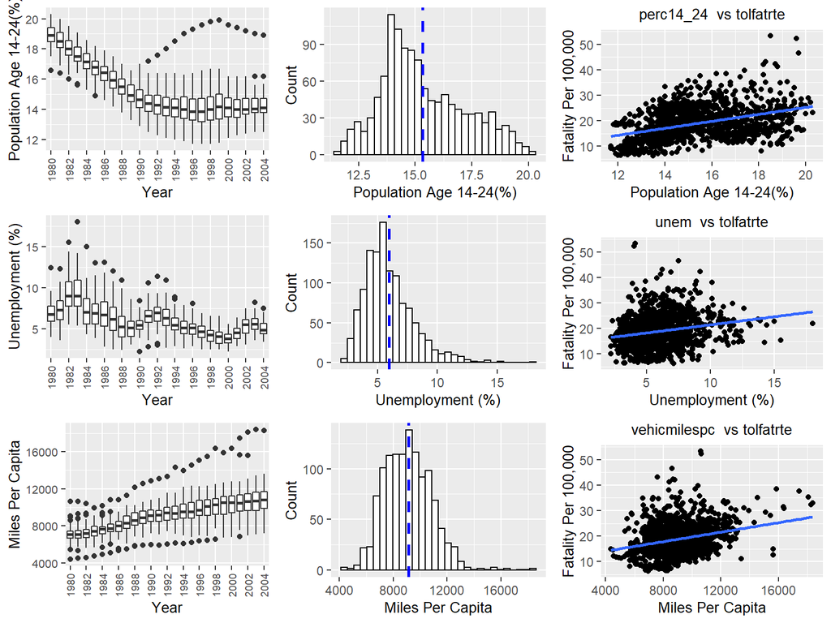

Univariate and Bivariate EDA of Factors Unrelated to Traffic Laws

```r
p1a <- plotbox(data, "perc14_24", "Population Age 14-24(%)")
p2a <- plotbox(data, "unem", "Unemployment (%)")
p3a <- plotbox(data, "vehicmilespc", "Miles Per Capita")

p1b <- plothist(data, "perc14_24", "Population Age 14-24(%)")
p2b <- plothist(data, "unem", "Unemployment (%)")
p3b <- plothist(data, "vehicmilespc", "Miles Per Capita")

p1c <- plotscatter(data, "perc14_24", "Population Age 14-24(%)")
p2c <- plotscatter(data, "unem", "Unemployment (%)")
p3c <- plotscatter(data, "vehicmilespc", "Miles Per Capita")

grid.arrange(p1a, p1b, p1c, p2a, p2b, p2c, p3a, p3b, p3c, ncol = 3)
```

There are six variables corresponding to speed limit laws, one each for 55, 65, 70, 75 mph limit, one for no speed limit, and one for speed limit 70 and over or no limit. These are not binary indicator variables. They contain decimal values to indicate proportion of the year when a law is in effect in the event a law is enabled in the middle of a year. Figure shows the number of states enforcing each speed limit over time, with yearly averaged fatality rate superimposed. When there are two different speed limits in a year, the speed limit in-effect for majority of the year is considered the speed limit for the purpose of the plot. In the special case where it’s a 50-50 split, the higher speed limit used used. In general, speed limit is increasing over time across the US starting in the late 80s. This is possibly due to the cars in general getting faster and roads getting better. It’s worth noting that the small peak in fatality rate in the late 80s coincides with the first two years of speed limit increase. It’s possible that driving was more dangerous in the initial years while people adapted to the faster speed limit. For the regression, speed limit over 70 mph or no limit (`sl70plus`) is used as the explanatory variable.

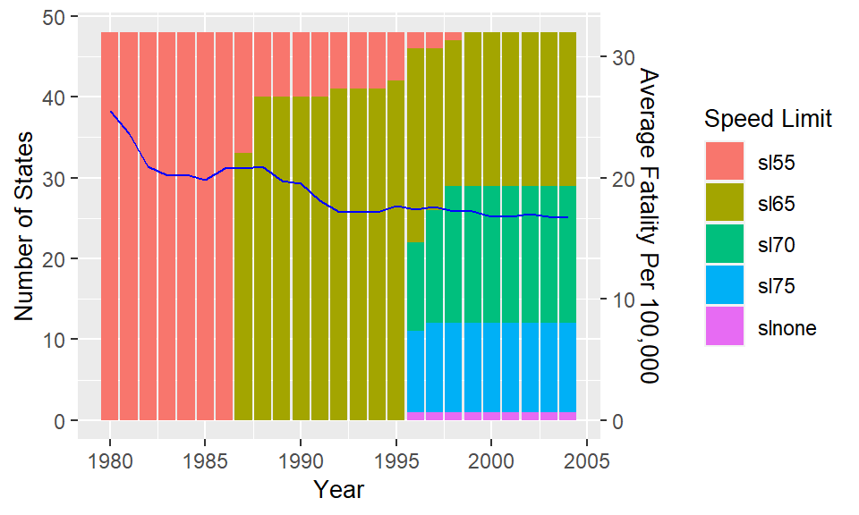

Speed Limit Distribution Over Time with Total Fatality Rate Superimposed

```r
## generic plot function for stacked charts
genplot <- function(grouped_df, legend){
  names(grouped_df) <- c("Year", "condition", "n")
  bar.plot <- ggplot()+ geom_bar(data = grouped_df, aes(fill=condition, y=n, x=Year),
              position="stack", stat = "identity") + geom_line(data = year_avg,
              aes(x = year, y = avg_totfatrte * 1.5), colour = "blue") + formatting +
              scale_y_continuous(sec.axis = sec_axis(trans = ~ . / 1.5, name = "Average Fatality Per 100,000")) +
              guides(fill=guide_legend(title=legend)) +ylab("Number of States")
  return (bar.plot)
}

data <- data %>%
    mutate(sl = case_when(
      sl55 > 0.5 ~ "sl55",
      sl65 > 0.5 ~ "sl65",
      sl70 > 0.5 ~ "sl70",
      sl75 > 0.5 ~ "sl75",
      slnone > 0.5 ~ "slnone",
      sl55 == 0.5 & sl65 == 0.5 ~ "sl65",
      sl65 == 0.5 & sl70== 0.5 ~ "sl70",
      sl65 == 0.5 & sl75== 0.5 ~ "sl75"
    ))


data %>% group_by(year, sl) %>% tally() %>% genplot("Speed Limit")
```

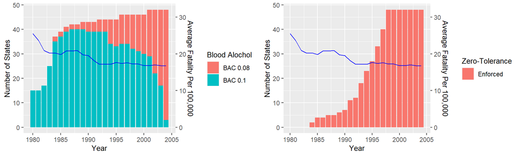

Enforcement of Laws Regarding Alcohol with Total Fatality Rate Superimposed

```r
data <- data %>%
    mutate(bac = case_when(
      bac10 > 0.5 ~ "BAC 0.1",
      bac08 > 0.5 ~ "BAC 0.08",
      bac08 == 0.5 & bac10== 0.5 ~ "BAC 0.1",
    ), zerotol_bin = case_when(zerotol > 0.5 ~ "Enforced")
    )

p1 <- data[!is.na(data$bac),] %>% group_by(year, bac) %>% tally() %>% genplot("Blood Alochol")
p2 <- data[!is.na(data$zerotol_bin),]%>% group_by(year, zerotol_bin) %>% tally() %>% genplot("Zero-Tolerance")

grid.arrange(p1,p2, nrow = 1)
```

`seatbelt` indicates seatbelt laws, possible values are primary, secondary, or none. `sbprim` and `sbsecond` are binary indicator variables representing the same information. Other variables concerning traffic laws are graduated drivers license law (`gdl`), administrative license revocation (`perse`). Similar to the speed limit variables, `gdl` and `perse` also contain decimals to represent laws in effect for parts of a year. They were also binarized for the bargraph visualizations (see Figure ). Seatbelts laws were first implemented in 1985 and saw near total adoption by 1995. Increasing number of states adopted primary seatbelt laws starting mid 90s. Overall, seatbelt laws is inversely correlated to fatality rate, though due to its absence in early 80s, it did not contribute to the initial decrease in fatality. Graduated Driver License Law first began in 1996 and dramatically increased in enforcement over the next decade. By mid 90s, the fatality rate was already steady, so `gdl` does not have an obvious impact on fatality. Per Se Law became increasingly common starting early 80s, and is inversely correlated to fatality rate.

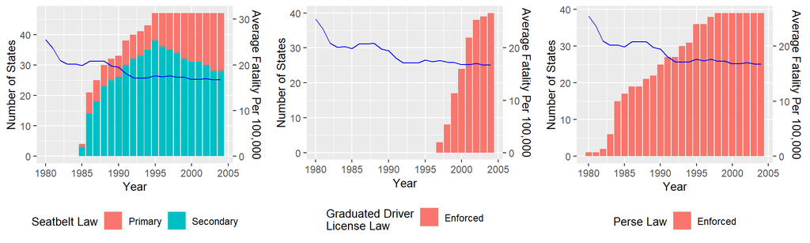

Enforcement of Traffic Laws with Total Fatality Rate Superimposed

```r
data <- data %>%
    mutate(seatbelt_bin = case_when(seatbelt == 1 ~ "Primary",seatbelt == 2 ~ "Secondary")
      , gdl_bin =  case_when(gdl > 0.5 ~ "Enforced"),
    perse_bin = case_when(perse > 0.5 ~ "Enforced"))

p1 <- data[!is.na(data$seatbelt_bin),] %>% group_by(year, as.factor(seatbelt_bin)) %>% tally() %>% genplot("Seatbelt Law") + theme(legend.position="bottom")
p2 <- data[!is.na(data$gdl_bin),] %>% group_by(year, gdl_bin) %>% tally() %>% genplot("Graduated Driver\nLicense Law")+ theme(legend.position="bottom")
p3 <- data[!is.na(data$perse_bin),] %>% group_by(year, perse_bin) %>% tally() %>% genplot("Perse Law")+ theme(legend.position="bottom")

grid.arrange(p1,p2,p3, nrow = 1)
```

Finally, correlation plot (Figure ) provides a cursory look at the relationship between the predictors and the outcome variable `totfatrte`. None of the predictors have exceptionally high correlation with fatality rate. `sl70plus`, `vehicmilespc`, `perc14_24`, `unem` have positive contemporaneous correlation to the outcome variable, and the rest have negative correlation. As previously noted in the bivariate scatterplot (Figure ), `perc14_24` has the strongest correlation to `totfatrte`. Among the predictors, in general the traffic law variables correlate positively to each other. `bac08` and `bac10` have strong negative correlation, which is expected, since a state can have only one of these two laws in effect at a time. `unem` has a notable negative correlation to `vehicmillespc`, which also makes intuitive sense, since higher unemployment rate would mean less commuting for work. Another well-correlated pair of predictors are `vehicmilespc` and `sl70plus`, implying that people travel more for places with less restrictive speed limit. Although `perse` is well correlated to `vehicmilespc`, this may be a coincidence since perse laws were increasingly enforced, while per capita miles travels were also increasing in time. None of the predictor variables of interest have perfect correlation so the lack of perfect correlation assumption for linear regression is satisfied.

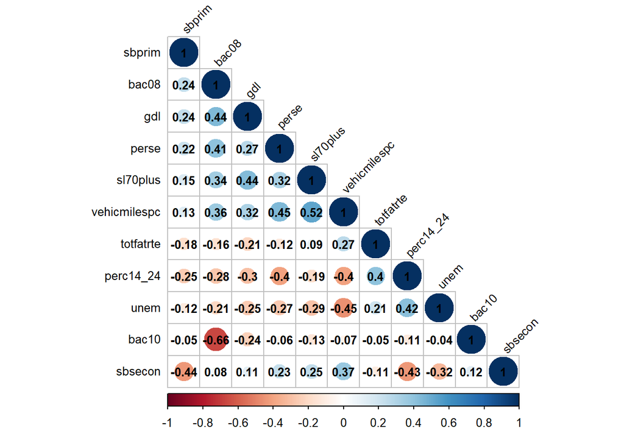

Correlation Matrix of Predictor Variables and Fatality Rate

```r
library(corrplot)
res2 <- cor(data[, c('totfatrte', 'bac08', 'bac10', 'perse', 'sbprim', 'sbsecon', 'sl70plus', 'gdl', 'perc14_24', 'unem', 'vehicmilespc')])
col<- colorRampPalette(c("blue", "white", "red"))(20)
corrplot(res2, type = 'lower', order = "hclust",  addCoef.col = "black",
         tl.col = "black", tl.srt = 45, tl.cex=0.8, number.cex = 0.8)
```

2. (15%) How is the our dependent variable of interest *totfatrte* defined? What is the average of this variable in each of the years in the time period covered in this dataset? Estimate a linear regression model of *totfatrte* on a set of dummy variables for the years 1981 through 2004. What does this model explain? Describe what you find in this model. Did driving become safer over this period? Please provide a detailed explanation.

The *totfatrte* is defined as the total fatality per 100,000 people. The average in each year can be calculated as a simple average or weighted average after controlling for each state’s population size, as shown in the table below. In 1980, the simple and weighted annual average of `totfatrte` is 25.49 and 22.61, respectively. In comparison, in 2004, the simple and weighted annual average of `totfatrte` is 16.73 and 14.54. In general, the fatality rates are decreasing over time, and the weighted average is lower than simple average in the same year, because some of the more populated states have lower fatality rate.

```r
# totfat averaged factoring population
weighted_avg <- data %>% group_by(year) %>% summarise(avg_totfatrte_weighted = sum(totfat)*100000/sum(statepop), .groups = 'drop')
year_avg$avg_totfatrte_weighted <- weighted_avg$avg_totfatrte_weighted

kable(year_avg, caption = "Yearly Average of Total Fatality Rate")
```

Yearly Average of Total Fatality Rate

| year | avg_totfatrte | avg_totfatrte_weighted |
| --- | --- | --- |
| 1980 | 25.49458 | 22.61325 |
| 1981 | 23.67021 | 21.54580 |
| 1982 | 20.94250 | 19.00720 |
| 1983 | 20.15292 | 18.23027 |
| 1984 | 20.26750 | 18.79777 |
| 1985 | 19.85146 | 18.45940 |
| 1986 | 20.80042 | 19.26071 |
| 1987 | 20.77479 | 19.21391 |
| 1988 | 20.89167 | 19.31130 |
| 1989 | 19.77229 | 18.51417 |
| 1990 | 19.50521 | 17.91138 |
| 1991 | 18.09479 | 16.43934 |
| 1992 | 17.15792 | 15.32955 |
| 1993 | 17.12771 | 15.46917 |
| 1994 | 17.15521 | 15.50936 |
| 1995 | 17.66854 | 15.74177 |
| 1996 | 17.36938 | 15.64513 |
| 1997 | 17.61062 | 15.44655 |
| 1998 | 17.26542 | 15.08738 |
| 1999 | 17.25042 | 15.00136 |
| 2000 | 16.82562 | 14.93093 |
| 2001 | 16.79271 | 14.81142 |
| 2002 | 17.02958 | 14.97254 |
| 2003 | 16.76354 | 14.76937 |
| 2004 | 16.72896 | 14.54297 |

While total fatality rate is decreasing over the 25 year period, it doesn’t necessarily mean driving has become safer. Firstly, driving safety encompasses both fatality rate in accidents, as well as accident rates in general. This dataset does not capture overall accident rates, so it’s possible that vehicular accident rates remained the same or even increased over time, but because the newer car models have better safety features, drivers are much less likely to be injuried or killed in accidents and hence the drop in fatality rate. Additionally, because the fatalty rate per fixed population rate, changes in demographics or lifestyle could indirectly lead to what appears to be decreasing fatality rate. For example, most major metropolises are growing in population size over time, and people living in the city tend to travel using means other than private vehicles. Along the same veins, in recent years, due to combination of improvement in public transit and environment advocacy, more people are shifting to public transportation. These people would be included in the denominator for traffic fatality rate, while not contributing much to the numerator, which would lower the total fatality rate as defined in this dataset.

```r
q2.lm <- lm(log(totfatrte)~d81+d82+d83+d84+d85+d86+d87+d88+d89+d90+d91+d92+d93+d94+d95+d96+d97+d98+d99+d00+d01+d02+d03+d04, data=data)
q2.lm.se = sqrt(diag(vcovHC(q2.lm)))
```

3. (15%) Expand your model in *Exercise 2* by adding variables *bac08, bac10, perse, sbprim, sbsecon, sl70plus, gdl, perc14_24, unem, vehicmilespc*, and perhaps *transformations of some or all of these variables*. Please explain carefully your rationale, which should be based on your EDA, behind any transformation you made. If no transformation is made, explain why transformation is not needed. How are the variables *bac8* and *bac10* defined? Interpret the coefficients on *bac8* and *bac10*. Do *per se laws* have a negative effect on the fatality rate? What about having a primary seat belt law? (Note that if a law was enacted sometime within a year the fraction of the year is recorded in place of the zero-one indicator.)

We chose to not binarize the variables representing enactment of laws (`bac08`, `bac10`, `perse`, `sbprim`, `sbsecon`, `sl70plus`, `gdl`). From an intuitive perspective, if a law has effect on traffic fatality, implmenting it middle of the year should result in that year’s fatality rate averaging out to be somewhere in between if the law was in full effect the whole year and entirely not enacted the whole time. Binarizing the predictors would lose this meaningful relationship. By leaving the variables as decimals, the variables can be interpreted as the fraction of year when the law is effective, instead of an indicator variable representing simple presence or absence of a law.

As for the numerical variables, as seen in the EDA histogram in (Figure ), `perc14_24` is asymmetric but not strongly skewed. Therefore a log transformation is not necessary. In contrast, `unem`, `vehicmilespc` as well as the outcome variable `totfatrte` were shown in the EDA to be obviously skewed in the positive direction, and `vehicmilespc` has increasing variance over time. This makes them good candidates for log transformation. Additionally, Shapiro-Wilk normality test shows that the linear model with untransformed variable would result in non-normal residuals (P = 9.96e-13), while residuals after transforming `vehicmilespc` and `totfatrte` is normally distributed (p = 0.14). For this reason, log-transformation of these variables are preferred.

$$\begin{align*}
\log(totfatrte) =& -11.07 -0.096d81 -0.32d82 \cdots -1.02d03 -1.01d04 -0.0577bac08 -0.016bac10-0.025perse\\
&+0.014sbprim + 0.031sbsecon + 0.24 sl70plus -0.029gdl + 0.016oerc14_24 _ 0.041\log(unem) + 1.54\log(vehicmilespc)
\end{align*}$$

```r
q3.untransformed <- lm(totfatrte~factor(year)+ bac08+bac10+perse+sbprim+sbsecon+sl70plus+gdl+perc14_24+unem+vehicmilespc, data=data)

shapiro.test(residuals(q3.untransformed))
```

```
##
##  Shapiro-Wilk normality test
##
## data:  residuals(q3.untransformed)
## W = 0.97747, p-value = 9.96e-13
```

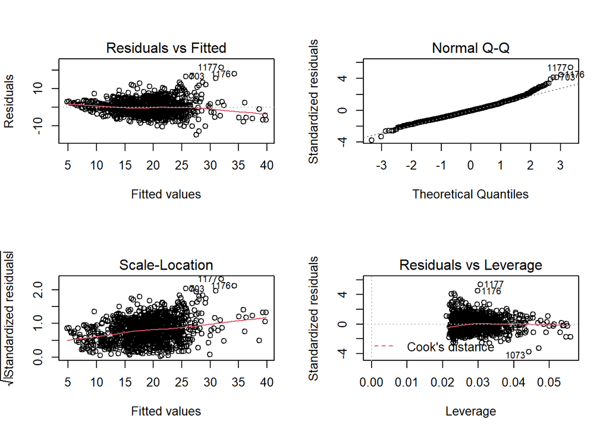

```r
par(mfrow=c(2,2))

plot(q3.untransformed)
```

```r
q3.lm <- lm(log(totfatrte)~d81+d82+d83+d84+d85+d86+d87+d88+d89+d90+d91+d92+d93+d94+d95+d96+d97+d98+d99+d00+d01+d02+d03+d04+
               bac08+bac10+perse+sbprim+sbsecon+sl70plus+gdl+perc14_24+log(unem)+log(vehicmilespc), data=data)

q3.lm.se = sqrt(diag(vcovHC(q3.lm)))
shapiro.test(residuals(q3.lm))
```

```
##
##  Shapiro-Wilk normality test
##
## data:  residuals(q3.lm)
## W = 0.99793, p-value = 0.141
```

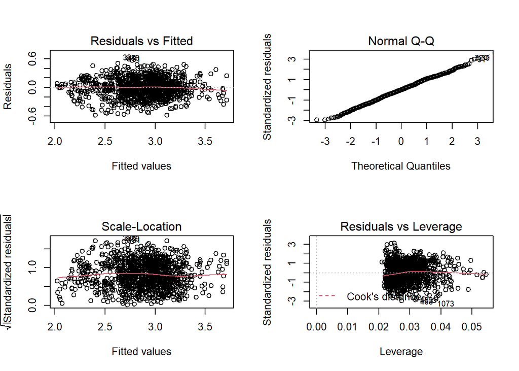

Diagnostic Plots of the Pooled OLS

```r
par(mfrow=c(2,2))
plot(q3.lm)
```

4. (15%) Reestimate the model from *Exercise 3* using a fixed effects (at the state level) model. How do the coefficients on *bac08, bac10, perse, and sbprim* compare with the pooled OLS estimates? Which set of estimates do you think is more reliable? What assumptions are needed in each of these models? Are these assumptions reasonable in the current context?

See table in Appendix A for complete table of coefficients with comparison to the model in Exercise 3. In the fixed effects model, the coefficients for `bac8` and `sbsecon` are not significant, the coefficient for `bac10` and `gdl` are marginally significant at the 10% level. The rest of the coefficients are significant at the 5% level. In comparison to the pooled OLS, in the fixed effect model, the coefficient for `bac08` became smaller and non-significant; the coefficient for `bac10` increased, its SE decreased, so the p-value is closer to significance though its still not significant at 5%; `perse` became highly significant; `sbprim` became significant as well.

The fixed effect model allows for arbitrary correlation between the unobserved effect and the explanatory variables in any time period, and only requires the idiosyncratic error to be uncorrelated to the predictors.The other assumptions are similar to that of the pooled OLS model. QQ-plot of the residual shows rough normalit (Figure ). The residual vs fitted plot shows the idiosyntractic error to have approximately mean of zero, so exogeneity assumption is likely met. Absence of perfect linear relationship was confirmed through correlation matrix, and none of the explanatory variables included in the model are time invariant. The residuals for the fixed effect model is heteroskedastic according to Breusch–Pagan test (p = 1.81e-07). This issue is addressed by using heteroskedastic robust coefficients. Lastly, the model assumes no serial correlation between the idiosyncratic errors conditional on all explanatory variables and unobserved effects. This is the most problematic assumption this specific model. The Breusch-Godfrey test suggested there is serial correlation in idiosyncratic errors (p <2.2e-16). In conjunction to the violation of heteroskedasticity, we could potentially address this by using heteroskedasticity and autocorrelation consistent standard error, or include lag terms in the regression to attempt to remove the serial correlation in the error.

Taking in account of the shortcomings of both models, the estimates from the Fixed-Effect model are more reliable. The assumption of no correlation between composit error ($a_i + u_{it}$) is unlikely to be true for the pool OLS to give unbiased estimates. Intuitive example of such violation is a state’s geographical features and city layouts. The layout of cities in each state is mostly time invariant, and it would have a tangible impact on one of the predictors, the amount of traveling by vehicle per capita. Simultaneously, it would have a direct effect on vehicle accidental fatality rate. States with closely packed cities and narrow streets are likely to end up with higher accidental rate and higher fatalities.

```r
panel_data <- pdata.frame(data, c("state", "year"))
q4.fe <- plm(log(totfatrte) ~ d81+d82+d83+d84+d85+d86+d87+d88+d89+d90+d91+d92+d93+d94+d95+d96+d97+d98+d99+d00+d01+d02+d03+d04+
               bac08 + bac10 + perse + sbprim + sbsecon + sl70plus + gdl + perc14_24 + log(unem) + log(vehicmilespc), data = panel_data, model = "within")
q4.fe.se = sqrt(diag(vcovHC(q4.fe)))

bptest(q4.fe, studentize = F)
```

```
##
##  Breusch-Pagan test
##
## data:  q4.fe
## BP = 93.568, df = 34, p-value = 1.811e-07
```

```r
pbgtest(q4.fe)
```

```
##
##  Breusch-Godfrey/Wooldridge test for serial correlation in panel models
##
## data:  log(totfatrte) ~ d81 + d82 + d83 + d84 + d85 + d86 + d87 + d88 +     d89 + d90 + d91 + d92 + d93 + d94 + d95 + d96 + d97 + d98 +     d99 + d00 + d01 + d02 + d03 + d04 + bac08 + bac10 + perse +     sbprim + sbsecon + sl70plus + gdl + perc14_24 + log(unem) +     log(vehicmilespc)
## chisq = 219.61, df = 25, p-value < 2.2e-16
## alternative hypothesis: serial correlation in idiosyncratic errors
```

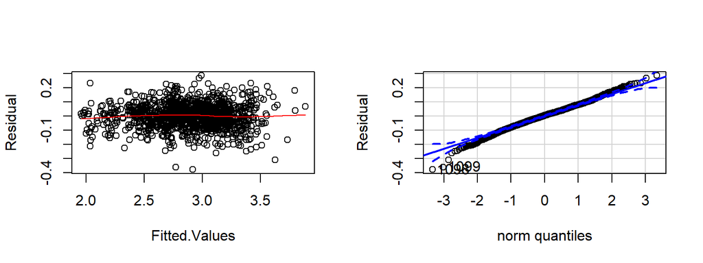

Residual vs. Fitted and QQ-plot for Fixed Effects Model

```
## [1] 1098 1099
```

```r
par(mfrow=c(1,2 ))

Fitted.Values <- as.numeric(q4.fe$model[[1]] - q4.fe$residuals)
Residual <- as.numeric(q4.fe$residuals)

scatter.smooth(Fitted.Values, Residual, lpars = list(col = "red", lwd = 1, lty = 1))

qqPlot(Residual)
```

5. (10%) Would you perfer to use a random effects model instead of the fixed effects model you built in *Exercise 4*? Please explain.

The fixed effects model is more preferred over the random effects model. Hausman test also rejects the null-hypothesis that the random effect model is consistent (p = 1.675e-05). The main issue with the random effect model is that it assumes the unobserved effect given all explanatory variables is constant, that is, there is no correlation between the unobserved effect and the explanatory variables. As discussed perviously, this assumption is unlikely to hold. On the flip side, because we are not using any time-invariant variables as predictors, fixed effect model can estimate the effects of all predictors on `totfatrte`.

```r
q5.re <-plm(log(totfatrte) ~ d81+d82+d83+d84+d85+d86+d87+d88+d89+d90+d91+d92+d93+d94+d95+d96+d97+d98+d99+d00+d01+d02+d03+d04+
               bac08 + bac10 + perse + sbprim + sbsecon + sl70plus + gdl + perc14_24 + log(unem) + log(vehicmilespc), data = panel_data, model = "random")
q5.re.se = sqrt(diag(vcovHC(q5.re)))

phtest(q4.fe, q5.re)
```

```
##
##  Hausman Test
##
## data:  log(totfatrte) ~ d81 + d82 + d83 + d84 + d85 + d86 + d87 + d88 +  ...
## chisq = 79.459, df = 34, p-value = 1.675e-05
## alternative hypothesis: one model is inconsistent
```

6. (10%) Suppose that *vehicmilespc*, the number of miles driven per capita, increases by $1,000$. Using the FE estimates, what is the estimated effect on *totfatrte*? Please interpret the estimate.

Due to the log transformation of `totfatrte` and `vehicmilespc`, there isn’t a constant estimated effects from a raw increase of miles driven per capita. Holding all others constant, if `vehicmilespc` is originally 10,000 miles, increasing it by 1,000 miles is a 10% increase, then according to the Fixed Effect model’s coefficient for `log(vehicmilespc)`, it would result in a 6.59% increase in total fatality rate. Compare to this, if `vehicmilespc` was originally 5,000 or 20,000, increasing it by 1,000 miles would lead to 13.18% and 3.30% increase in `totfatrte`, respectively.

7. (5%) If there is serial correlation or heteroskedasticity in the idiosyncratic errors of the model, what would be the consequences on the estimators and their standard errors?

If there is serial correlation or heteroskedasticity in the idiosyncratic errors of the model, the errors would be closer together and the standard errors are smaller than they should be. Consequently, the p-values obtained would be smaller than it should be and it would be easier to obtain a significant coefficient comparing to how significant it is in reality. One way to address this is to use clustering to obtain fully robust standard errors and test statistics. The fixed effect model in this analysis has both serial correlation and heteroskedasticity in the residuals according to Breusch-Godfrey and Breusch-Pagan test, respectively. Without using heteroskedasticity and autocorrelation consistent standard errors, we should consider the possibility that some of the marginally significant coefficients are in reality not significant.

###Appendix A Regression Model Results from Questions 2-6, using heteroskedastic robust standard error.

```r
stargazer(q2.lm, q3.lm, q4.fe, q5.re, type = "latex", single.row = TRUE,
          se = list(q2.lm.se, q3.lm.se, q4.fe.se, q5.re.se),
          column.labels = c("Pooled OLS with Time Dummies", "Pooled OLS", "Fixed Effect Model", "Random Effect Model"),
          star.cutoffs = c(0.05, 0.01, 0.001))
```

[output not shown]